# Bagging - cancer relapse

V. Monbet (UR1)

3 octobre 2020

## Cancer relapse prediction from micro array data

The dataset contains 97 observations with 44 cases of relapse. And 754 gene expressions are recarded.

```r
library(caret)
```

```r
library(ipred)
library(rpart)
library(ggplot2)
library(pROC)
library(ada)
library(randomForest)
# Cancer Relapse dataset
X.all = read.table("https://perso.univ-rennes1.fr/valerie.monbet/MachineLearning/Ex2_breast_cancer_ER_train_set_for_other_methods.gct",skip=2,header=TRUE,sep = "\t")
label = read.table("https://perso.univ-rennes1.fr/valerie.monbet/MachineLearning/Ex2_breast_cancer_ER_train_set_class_labels.cls",skip=2,header=FALSE,sep = " ")


#chemin = "~/Documents/ENSEIGNEMENT/MACHINE LEARNING/Master BMC/PROJETS/Ex_datasets/Ex2/"
#X.all = read.table(paste(chemin,"Ex2_breast_cancer_ER_train_set_for_other_methods.gct",sep=""),skip=2,header=TRUE,sep = "\t")
#label = read.table(paste(chemin,"Ex2_breast_cancer_ER_train_set_class_labels.cls",sep=""),skip=2,header=FALSE,sep = " ")

X.desc = X.all[,1]
X = t(X.all[,-c(1,2)])
colnames(X) = X.desc

y = factor(label,levels=c(0,1))

cancer_relapse = data.frame(X)
cancer_relapse$y = y
```

Let us first have a look to the data. Here, the fields library is used because it provides nice colors for plotting images.

```r
library(fields)
```

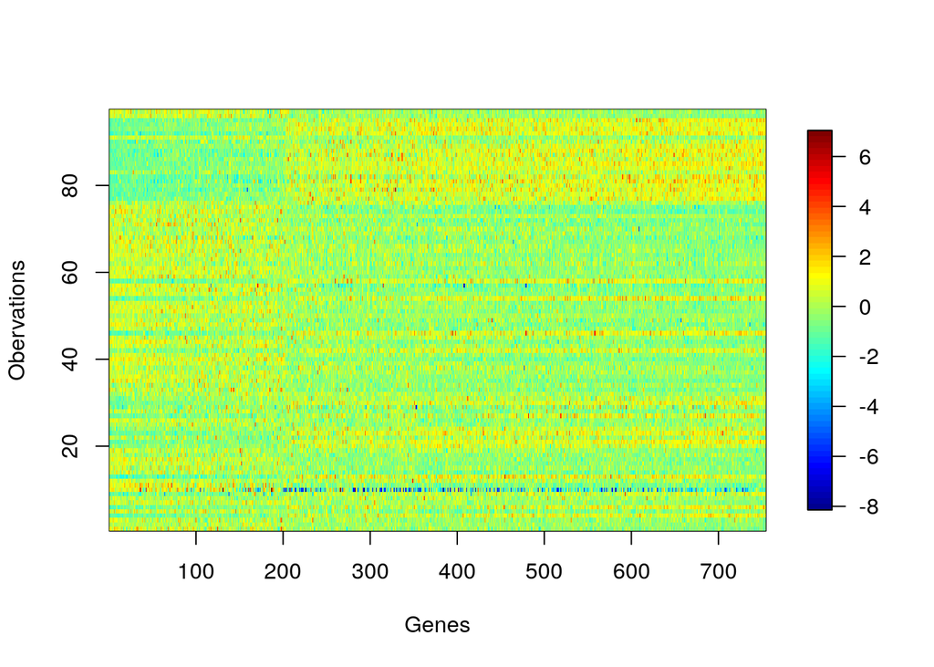

```r
image.plot(1:dim(X)[2],1:dim(X)[1],t(X),xlab="Genes",ylab="Obervations")
```

```r
table(y)
```

```
## y
##  0  1
## 53 44
```

We can start by computing the signal over noise ratio of the gene expressions

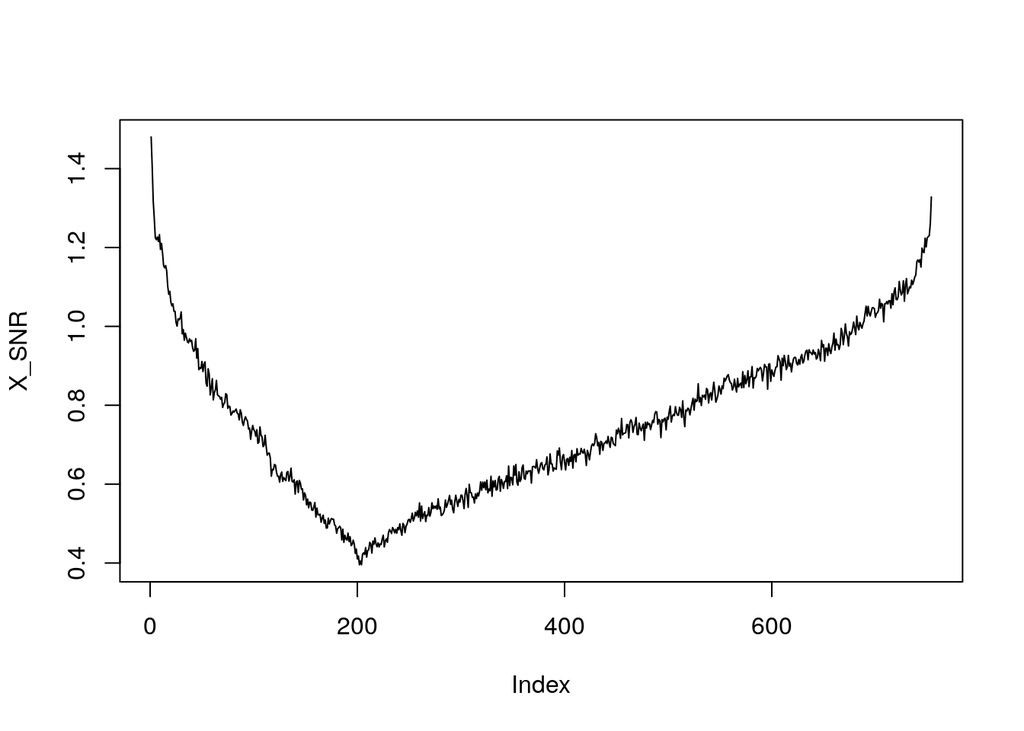

```r
# Function to find the genes with the highest SNR
genes_SNR = function(X,y){
  # - Inputs
  # X = dataset
  # y = labels (a boolean or factor variable)
  # - Output
  # SNR
  labels = unique(y)
  n = dim(X)[1]
  p = dim(X)[2]
  K = length(labels)

  means = matrix(0,length(labels),dim(X)[2])
  std = apply(X,2,sd)

  for (k in 1:K){means[k,] = apply(X[y==labels[k],],2,mean)}
  SNR = apply(matrix(abs(apply(means,2,diff)),K-1,p),2,max)/std
  return(SNR)
}

X_SNR = genes_SNR(X,y)
plot(X_SNR,typ="l")
```

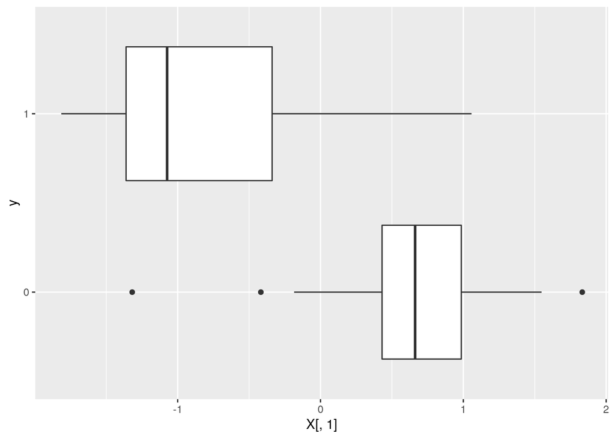

```r
library(ggplot2)
p <- ggplot(cancer_relapse, aes(x=X[,1], y=y)) +
  geom_boxplot()
p
```

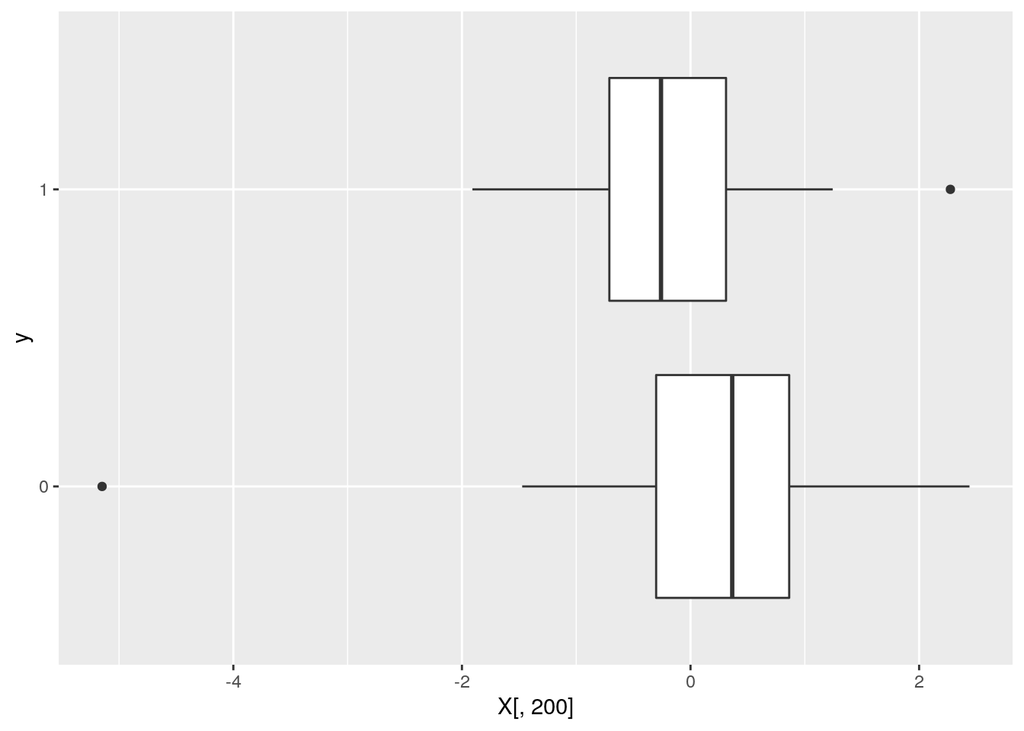

```r
p <- ggplot(cancer_relapse, aes(x=X[,200], y=y)) +
  geom_boxplot()
p
```

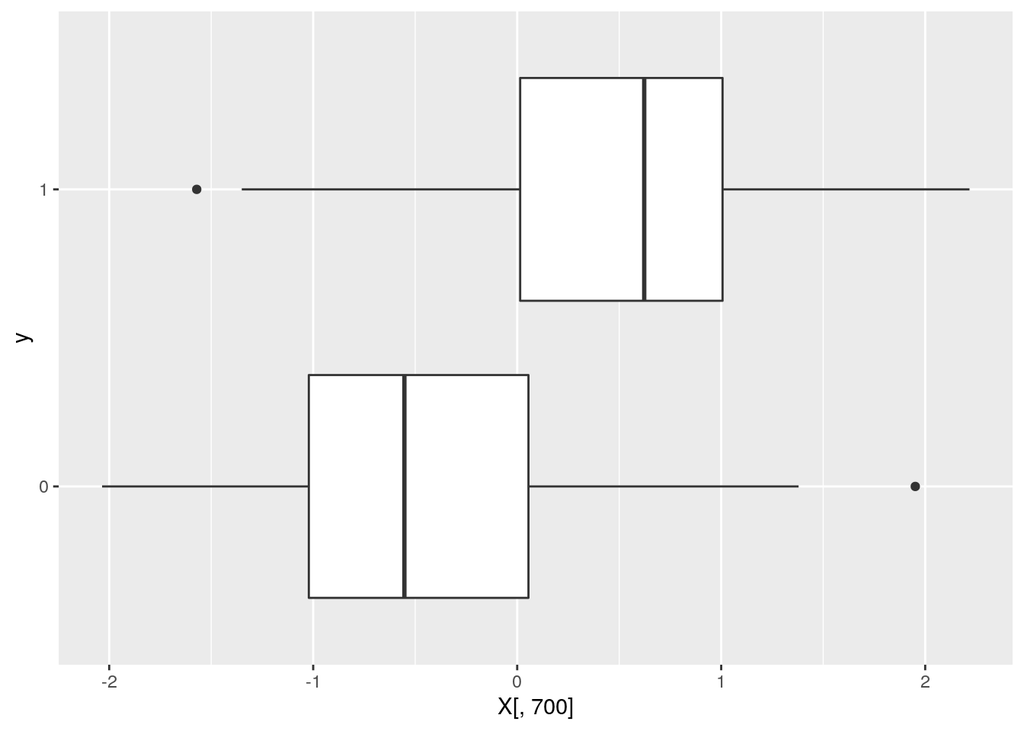

```r
p <- ggplot(cancer_relapse, aes(x=X[,700], y=y)) +
  geom_boxplot()
p
```

We work only with the genes which are differentially expressed. Some tests have been done previously and the AUC for boosting and bagging fit on all the genes is equal to 0.86.

```r
w = which(X_SNR/max(X_SNR)>.6)
print(paste("Number of variables kept :",length(w)))
```

```
## [1] "Number of variables kept : 213"
```

```r
X = X[,w]
cancer_relapse_select = data.frame(X)
cancer_relapse_select$y = y
```

## Bagging

We use the treebag algorithm available in caret. Take care the computational time is quite long...

```r
treebag_grid <-  expand.grid(k = c(1, 2, 5, 10))

set.seed(825)
fitControl <- trainControl(## 5-fold CV
                           method = "repeatedcv",
                           number = 5, # nb of folds
                           ## repeated 1 times
                           repeats = 1) # repeat should be increased...
treebagFit <- train(y ~ ., data = cancer_relapse_select,
                 preProcess=c("center", "scale"),
                 method = "treebag",
                 metric = "Accuracy",
                 verbose = TRUE,
                 trControl = fitControl,
                 allowParallel=TRUE)
treebagFit
```

```
## Bagged CART
##
##  97 samples
## 213 predictors
##   2 classes: '0', '1'
##
## Pre-processing: centered (213), scaled (213)
## Resampling: Cross-Validated (5 fold, repeated 1 times)
## Summary of sample sizes: 78, 78, 77, 78, 77
## Resampling results:
##
##   Accuracy   Kappa
##   0.8431579  0.6752008
```

```r
treebagFit$finalModel
```

```
##
## Bagging classification trees with 25 bootstrap replications
```

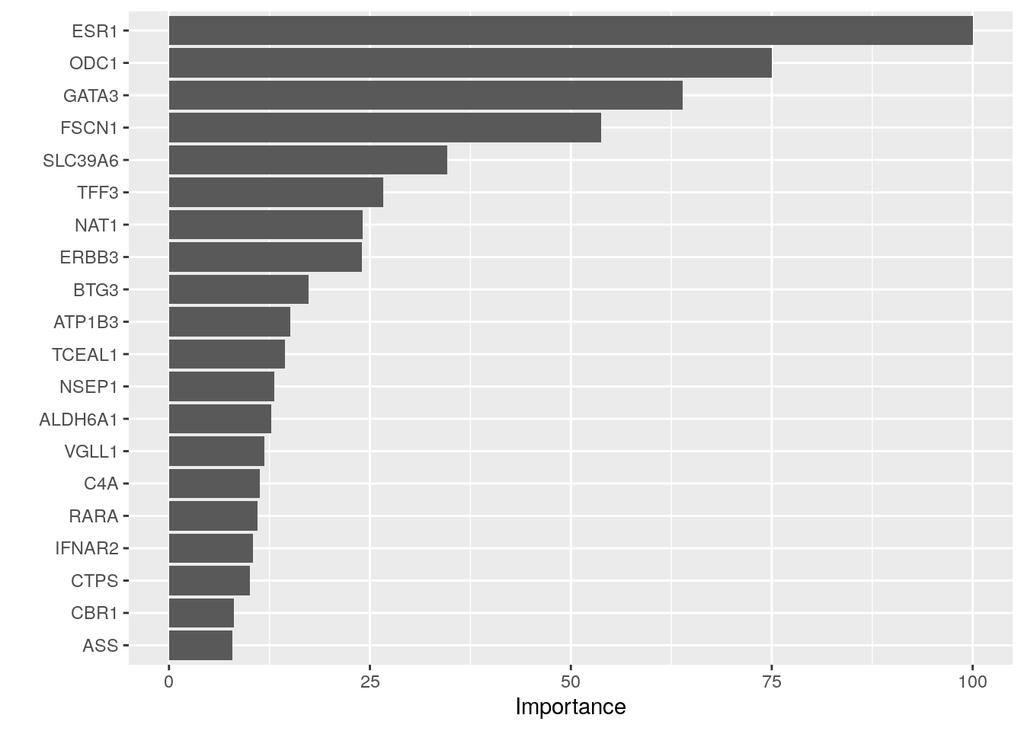

```r
vip::vip(treebagFit, num_features = 20)
```

THe training selects a bagging with 25 trees. Lets us train such an ensemble and plot the ROC curve.

```r
n = length(y)
itrain = sample(1:n,round(n*2/3))
itest = setdiff(1:n,itrain)
treebag = bagging(y ~ ., data = cancer_relapse, nbagg=25, control=
                 rpart.control(minsplit=2, cp=0, xval=0),subset = itrain)
y.prob.test = predict(treebag,cancer_relapse,typ="prob")[itest,2]
```

```r
res_roc = roc(y[itest],y.prob.test)
```

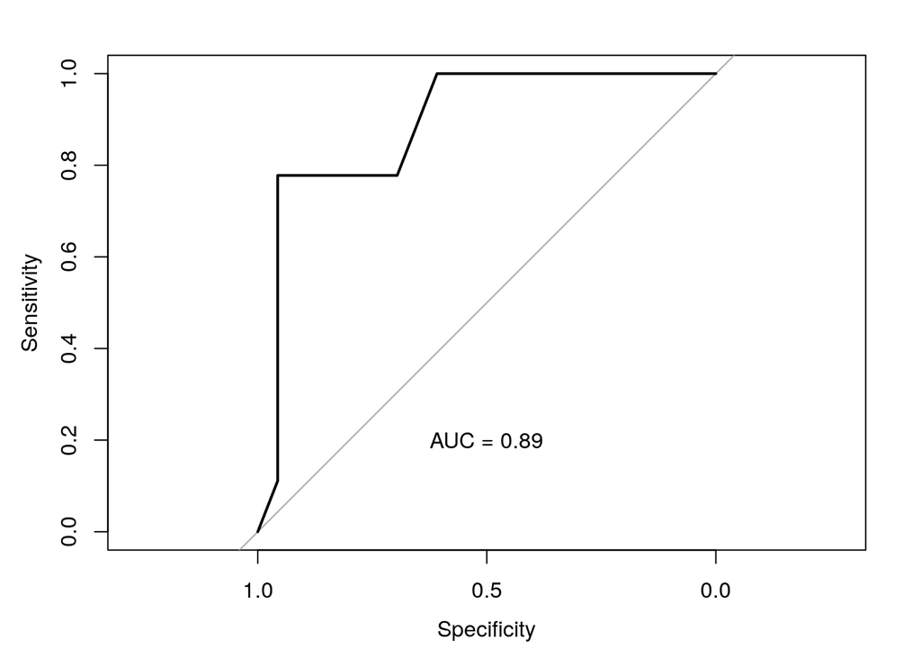

```r
plot(res_roc,xlim=c(1,0),ylim=c(0,1)) # ROC curve
text(.5,.2,paste("AUC =",round(res_roc$auc,2)))
```

The ROC curve is not smooth because only a few samples are considred in the test set. To improve the smoothness the experience can be repeated and the ROC curve plot for the concatenation of all the results.

Computation of the bagging may be long... Paralelization could be used.

```r
B = 10
y.test = y.prob.test = NULL
for (b in 1:B){
  itrain = sample(1:n,round(n*2/3))
  itest = setdiff(1:n,itrain)
  treebag = bagging(y ~ ., data = cancer_relapse, nbagg=25, control=
                   rpart.control(minsplit=2, cp=0, xval=0),subset = itrain)
  y.test = c(y.test,y[itest])
  y.prob.test = c(y.prob.test,predict(treebag,cancer_relapse,typ="prob")[itest,2])
}
```

```r
res_roc = roc(y.test,y.prob.test)
```

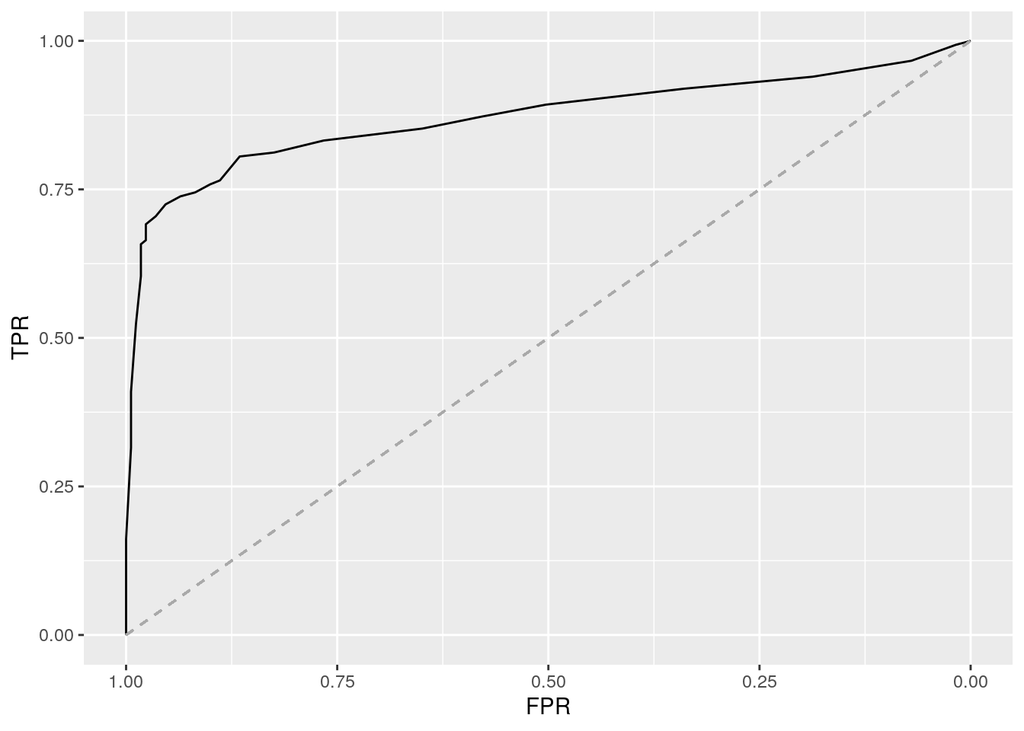

```r
library(ggplot2)
g <- ggroc(res_roc)
g + xlab("FPR") + ylab("TPR") +
    geom_segment(aes(x = 1, xend = 0, y = 0, yend = 1), color="darkgrey", linetype="dashed")
```

```r
print(paste("Bagging, AUC =",round(res_roc$auc,2)))
```

```
## [1] "Bagging, AUC = 0.87"
```

## Random forest

```r
n_features = dim(X)[2]
hyper_grid <- expand.grid(
  mtry = floor(n_features * c(.05, .15, .25, .333, .4)),
  min.node.size = c(1, 3, 5, 10),
  replace = c(TRUE, FALSE),
  sample.fraction = c(.5, .63, .8)
)

rfFit <- train(y ~ ., data = cancer_relapse,
                 preProcess=c("center", "scale"),
                 method = "rf",
                 metric = "Accuracy",
                 verbose = TRUE,
                 trControl = fitControl,
                 allowParallel=TRUE)
rfFit$finalModel
```

```
##
## Call:
##  randomForest(x = x, y = y, mtry = param$mtry, verbose = TRUE,      allowParallel = TRUE)
##                Type of random forest: classification
##                      Number of trees: 500
## No. of variables tried at each split: 2
##
##         OOB estimate of  error rate: 15.46%
## Confusion matrix:
##    0  1 class.error
## 0 50  3  0.05660377
## 1 12 32  0.27272727
```

```r
y.test = y.prob.test = NULL
for (b in 1:B){
  itrain = sample(1:n,round(n*2/3))
  itest = setdiff(1:n,itrain)
  treeRF = randomForest(X[itrain,],y[itrain], mtry=38, control=
                   rpart.control(minsplit=2, cp=0, xval=0))
  y.test = c(y.test,y[itest])
  y.prob.test = c(y.prob.test,predict(treebag,cancer_relapse,typ="prob")[itest,2])
}
```

```r
res_roc_rf = roc(y.test,y.prob.test)
```

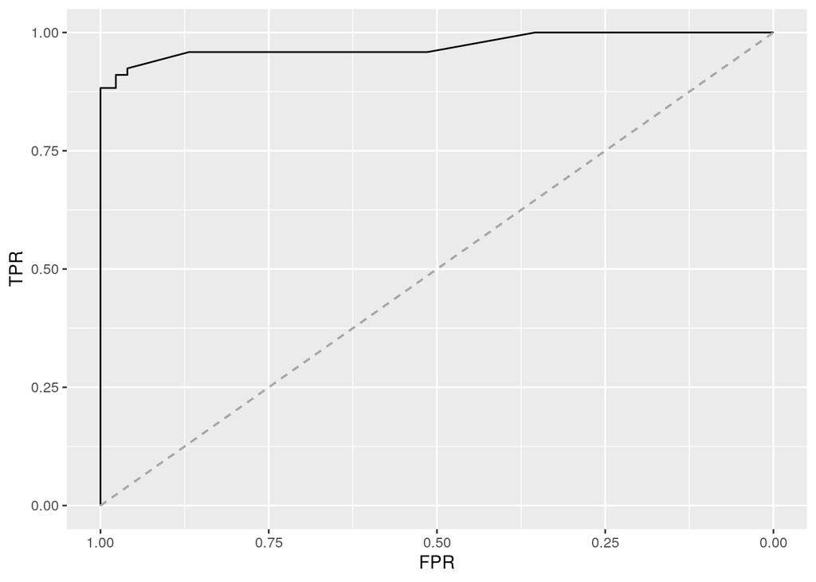

```r
library(ggplot2)
g_rf <- ggroc(res_roc_rf)
g_rf + xlab("FPR") + ylab("TPR") +
    geom_segment(aes(x = 1, xend = 0, y = 0, yend = 1), color="darkgrey", linetype="dashed")
```

```r
print(paste("Random Forest, AUC =",round(res_roc$auc,2)))
```

[output not shown]

## Boosting

The hyper parameter selection tools of caret is not run because the computaional time is to large...

```r
#treeboost_grid <-  expand.grid(iter = c(25,100,300))
#
#set.seed(825)
#fitControl <- trainControl(## 5-fold CV
#                           method = "repeatedcv",
#                           number = 5, # nb of folds
#                           ## repeated 1 times
#                           repeats = 1) # should be increased
#treeboostFit <- train(y ~ ., data = cancer_relapse,
#                 method = "ada",
#                 metric = "Accuracy",
#                 verbose = FALSE,
#                 trControl = fitControl)
#treeboostFit
```

```r
y.test = y.prob.test = NULL
for (b in 1:B){
  itrain = sample(1:n,round(n*2/3))
  itest = setdiff(1:n,itrain)
  treeboost = ada(X[itrain,], y[itrain],loss="exponential",
     type=c("discrete"),iter=50, nu=1, bag.frac=0.3)
  y.test = c(y.test,y[itest])
  y.prob.test = c(y.prob.test,predict(treeboost,cancer_relapse,typ="prob")[itest,2])
}
```

```r
res_roc_boost = roc(y.test,y.prob.test)
```

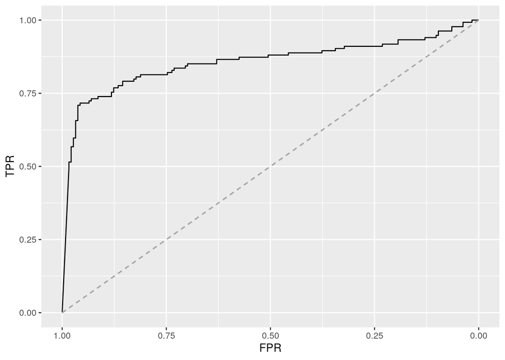

```r
g_boost <- ggroc(res_roc_boost)
g_boost + xlab("FPR") + ylab("TPR") +
    geom_segment(aes(x = 1, xend = 0, y = 0, yend = 1), color="darkgrey", linetype="dashed")
```

```r
print(paste("Boosting, AUC =",round(res_roc$auc,2)))
```

```
## [1] "Boosting, AUC = 0.87"
```

## Comparison

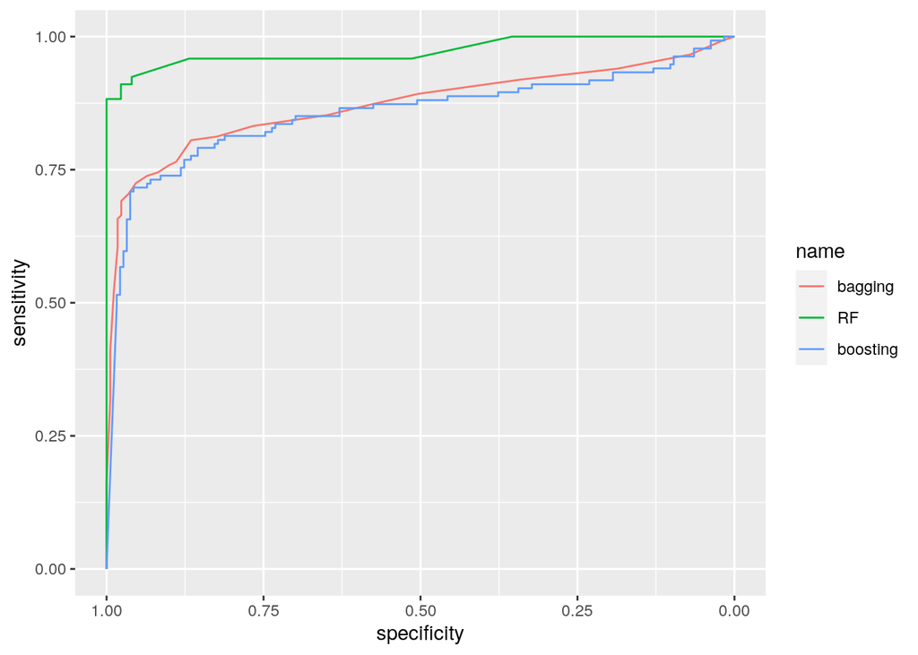

```r
g2 <- ggroc(list(bagging=res_roc, RF=res_roc_rf, boosting=res_roc_boost))
g2
```